# Intake Comparisons: RHMA & LARA

Sarai Hutchinson

2025-08-23

1. RHMA Intake 1.1 Read & Clean

```r
raw <- read_csv("C:\\Users\\sarai\\OneDrive\\Email attachments\\Documents\\UVI\\Thesis.Work\\SargMangs\\Data/RHMA_IntakeData.csv")
dat0 <- raw %>% clean_names()

dat1 <- dat0 %>%
  mutate(
    intake_date = parse_mdy_relaxed(intake_date),
    collection_date = {
      cd <- str_extract(collection_date, "\\b\\d{1,2}/\\d{1,2}/\\d{2,4}\\b")
      parse_mdy_relaxed(cd)
    },
    site = str_trim(as.character(site)),
    species = str_trim(as.character(species)),
    treatment = str_trim(as.character(treatment)),
    hypo_color = str_trim(as.character(hypo_color)),
    roots = str_trim(as.character(roots))
  )

num_cols <- c("diameter","epi_length","hypo_length","total_height","mass",
              "rhma_height_1","rhma_height_2")

dat2 <- dat1 %>%
  mutate(across(all_of(num_cols), ~ suppressWarnings(as.numeric(str_replace_all(.x, ",", "")))))

rhma_intake <- dat2 %>%
  filter(!is.na(intake_date)) %>%
  arrange(prop_id, intake_date) %>%
  group_by(prop_id) %>%
  slice(1) %>%
  ungroup()

glimpse(rhma_intake)
```

```
## Rows: 300
## Columns: 20
## $ collection_date <dttm> 2024-10-25, 2024-10-25, 2024-10-25, 2024-10-25, 2024-…
## $ intake_date     <dttm> 2024-10-25, 2024-10-25, 2024-10-25, 2024-10-25, 2024-…
## $ site            <chr> "OC", "OC", "OC", "OC", "OC", "OC", "OC", "OC", "OC", …
## $ species         <chr> "RHMA", "RHMA", "RHMA", "RHMA", "RHMA", "RHMA", "RHMA"…
## $ prop_id         <chr> "RA-1", "RA-10", "RA-11", "RA-12", "RA-13", "RA-14", "…
## $ treatment       <chr> "A", "A", "A", "A", "A", "A", "A", "A", "A", "A", "A",…
## $ diameter        <dbl> 13.2, 13.3, 13.1, 11.2, 12.8, 13.6, 12.3, 13.4, 13.4, …
## $ epi_length      <dbl> 2.0, 1.7, 2.0, 1.8, 1.9, 2.0, 1.9, 2.8, 1.8, 2.0, 1.9,…
## $ hypo_length     <dbl> 38.2, 36.0, 39.2, 29.4, 42.9, 31.7, 33.8, 46.0, 34.6, …
## $ total_height    <dbl> 40.2, 37.7, 41.2, 31.2, 44.8, 33.7, 35.7, 48.8, 36.4, …
## $ mass            <dbl> 33.63, 31.16, 34.34, 18.97, 34.31, 26.97, 26.81, 41.08…
## $ hypo_color      <chr> "G", "G", "B", "G", "G", "G", "G", "G", "G", "G", "G",…
## $ roots           <chr> "N", "Y", "Y", "Y", "Y", "Y", "Y", "Y", "Y", "Y", "Y",…
## $ rhma_height_1   <dbl> 21.3, 26.8, 24.3, 19.5, 31.5, 20.9, 23.2, 35.2, 22.4, …
## $ rhma_height_2   <dbl> 19.5, 24.1, 22.7, 17.1, 28.0, 18.5, 19.9, 32.5, 19.9, …
## $ rooting_tip     <chr> NA, NA, NA, NA, NA, NA, NA, NA, NA, NA, NA, NA, NA, NA…
## $ data_collecters <chr> "LG, SS", "LG, SS", "LG, SS", "LG, SS", "LG, SS", "LG,…
## $ date_uploaded   <chr> "10/25/2024", "10/25/2024", "10/25/2024", "10/25/2024"…
## $ data_uploaders  <chr> "LG", "LG", "LG", "LG", "LG", "LG", "LG", "LG", "LG", …
## $ notes           <chr> NA, NA, NA, NA, NA, NA, NA, NA, NA, NA, NA, NA, NA, NA…
```

1.2 QC flags

```r
qc_long <- rhma_intake %>%
  pivot_longer(all_of(num_cols), names_to = "metric", values_to = "value") %>%
  group_by(metric) %>%
  mutate(
    iqr = IQR(value, na.rm = TRUE),
    Q1 = quantile(value, 0.25, na.rm = TRUE),
    Q3 = quantile(value, 0.75, na.rm = TRUE),
    lower = Q1 - 3*iqr,
    upper = Q3 + 3*iqr,
    is_extreme = value < lower | value > upper
  ) %>%
  ungroup() %>%
  filter(is_extreme & !is.na(value)) %>%
  arrange(metric, desc(value))

head(qc_long %>% select(prop_id, site, treatment, metric, value, lower, upper), 20)
```

```
## # A tibble: 4 × 7
##   prop_id site  treatment metric       value lower upper
##   <chr>   <chr> <chr>     <chr>        <dbl> <dbl> <dbl>
## 1 RD-15   OC    D         diameter       2.9  6.52  18.6
## 2 RE-35   CP    E         hypo_length    2.3  6.90  55.2
## 3 RD-55   PR    D         mass          55.6 -7.85  55.5
## 4 RE-35   CP    E         total_height   3.4  7.83  57.7
```

```r
# readr::write_csv(qc_long, file.path(params$out_dir, "rhma_qc_flagged_values.csv"))
```

```r
library(dplyr)
library(purrr)
library(car)   # for leveneTest

# Helper function
check_normality_homogeneity <- function(data, traits, group_vars = c("site", "treatment")) {

  results <- map_dfr(traits, function(tr) {
    df <- data %>% select(all_of(c(group_vars, tr))) %>% drop_na()

    # Fit linear model for residuals
    formula <- reformulate(termlabels = paste(group_vars, collapse = "*"), response = tr)
    fit <- lm(formula, data = df)

    # Shapiro–Wilk on residuals
    shapiro_p <- tryCatch(shapiro.test(residuals(fit))$p.value, error = function(e) NA)

    # Levene's Test (robust to non-normality)
    lev <- tryCatch(leveneTest(df[[tr]] ~ interaction(df[[group_vars[1]]], df[[group_vars[2]]]))$`Pr(>F)`[1],
                    error = function(e) NA)

    # Bartlett’s Test (use only if residuals are normal)
    bart <- tryCatch(bartlett.test(df[[tr]] ~ interaction(df[[group_vars[1]]], df[[group_vars[2]]]))$p.value,
                     error = function(e) NA)

    tibble(
      trait = tr,
      shapiro_resid_p = shapiro_p,
      levene_p = lev,
      bartlett_p = bart
    )
  })

  return(results)
}
```

1.3 Summaries

```r
cont_traits <- c("diameter","epi_length","hypo_length","total_height","mass","rhma_height_1","rhma_height_2")
cat_traits  <- c("hypo_color","roots")

cont_summary <- rhma_intake %>%
  pivot_longer(all_of(cont_traits), names_to = "trait", values_to = "value") %>%
  group_by(site, treatment, trait) %>%
  summarise(
    n = sum(!is.na(value)),
    mean = mean(value, na.rm = TRUE),
    sd = sd(value, na.rm = TRUE),
    se = sd/sqrt(n),
    .groups = "drop"
  ) %>%
  mutate(mean_sd = sprintf("%.2f ± %.2f", mean, sd))

cat_summary <- purrr::map_dfr(cat_traits, function(tr){
  rhma_intake %>%
    count(site, treatment, !!sym(tr), name = "n") %>%
    group_by(site, treatment) %>%
    mutate(prop = n / sum(n)) %>%
    ungroup() %>%
    mutate(trait = tr) %>%
    rename(level = !!sym(tr))
})

rhma_norm_homo <- check_normality_homogeneity(rhma_intake, cont_traits)
rhma_norm_homo
```

```
## # A tibble: 7 × 4
##   trait         shapiro_resid_p levene_p bartlett_p
##   <chr>                   <dbl>    <dbl>      <dbl>
## 1 diameter             4.04e-12   0.572  0.00000792
## 2 epi_length           2.64e- 2   0.908  0.359
## 3 hypo_length          5.72e- 8   0.0611 0.0000107
## 4 total_height         3.27e- 8   0.194  0.0000641
## 5 mass                 6.80e- 6   0.231  0.00324
## 6 rhma_height_1        4.78e- 6   0.0179 0.0000406
## 7 rhma_height_2        4.86e- 7   0.0412 0.0000147
```

```r
rhma_norm_homo %>%
  mutate(
    normality_flag = if_else(shapiro_resid_p < 0.05, "Not Normal", "Normal"),
    homogeneity_flag = if_else(levene_p < 0.05, "Unequal Var", "Equal Var")
  )
```

```
## # A tibble: 7 × 6
##   trait      shapiro_resid_p levene_p bartlett_p normality_flag homogeneity_flag
##   <chr>                <dbl>    <dbl>      <dbl> <chr>          <chr>
## 1 diameter          4.04e-12   0.572  0.00000792 Not Normal     Equal Var
## 2 epi_length        2.64e- 2   0.908  0.359      Not Normal     Equal Var
## 3 hypo_leng…        5.72e- 8   0.0611 0.0000107  Not Normal     Equal Var
## 4 total_hei…        3.27e- 8   0.194  0.0000641  Not Normal     Equal Var
## 5 mass              6.80e- 6   0.231  0.00324    Not Normal     Equal Var
## 6 rhma_heig…        4.78e- 6   0.0179 0.0000406  Not Normal     Unequal Var
## 7 rhma_heig…        4.86e- 7   0.0412 0.0000147  Not Normal     Unequal Var
```

```r
rhma_norm_homo
```

```
## # A tibble: 7 × 4
##   trait         shapiro_resid_p levene_p bartlett_p
##   <chr>                   <dbl>    <dbl>      <dbl>
## 1 diameter             4.04e-12   0.572  0.00000792
## 2 epi_length           2.64e- 2   0.908  0.359
## 3 hypo_length          5.72e- 8   0.0611 0.0000107
## 4 total_height         3.27e- 8   0.194  0.0000641
## 5 mass                 6.80e- 6   0.231  0.00324
## 6 rhma_height_1        4.78e- 6   0.0179 0.0000406
## 7 rhma_height_2        4.86e- 7   0.0412 0.0000147
```

```r
knitr::kable(cont_summary %>% arrange(trait, site, treatment), caption = "RHMA continuous traits: mean ± sd by Site × Treatment")
```

RHMA continuous traits: mean ± sd by Site × Treatment

| site | treatment | trait | n | mean | sd | se | mean_sd |
| --- | --- | --- | --- | --- | --- | --- | --- |
| CP | A | diameter | 20 | 12.3700 | 1.2380375 | 0.2768336 | 12.37 ± 1.24 |
| CP | B | diameter | 20 | 11.2300 | 1.2888591 | 0.2881977 | 11.23 ± 1.29 |
| CP | C | diameter | 20 | 12.3750 | 1.0522532 | 0.2352910 | 12.38 ± 1.05 |
| CP | D | diameter | 20 | 11.4650 | 0.8585637 | 0.1919807 | 11.46 ± 0.86 |
| CP | E | diameter | 20 | 11.8650 | 1.2934145 | 0.2892163 | 11.87 ± 1.29 |
| OC | A | diameter | 20 | 12.7650 | 0.8418495 | 0.1882433 | 12.77 ± 0.84 |
| OC | B | diameter | 20 | 12.8450 | 0.9213691 | 0.2060244 | 12.85 ± 0.92 |
| OC | C | diameter | 20 | 12.5150 | 0.6915086 | 0.1546260 | 12.52 ± 0.69 |
| OC | D | diameter | 20 | 11.5800 | 2.1688221 | 0.4849634 | 11.58 ± 2.17 |
| OC | E | diameter | 20 | 12.4150 | 0.9538151 | 0.2132795 | 12.42 ± 0.95 |
| PR | A | diameter | 20 | 14.2350 | 1.0027725 | 0.2242267 | 14.23 ± 1.00 |
| PR | B | diameter | 20 | 13.7000 | 1.1220282 | 0.2508931 | 13.70 ± 1.12 |
| PR | C | diameter | 20 | 14.1000 | 0.8926601 | 0.1996049 | 14.10 ± 0.89 |
| PR | D | diameter | 20 | 12.9700 | 1.0969335 | 0.2452818 | 12.97 ± 1.10 |
| PR | E | diameter | 20 | 11.7500 | 1.6503588 | 0.3690314 | 11.75 ± 1.65 |
| CP | A | epi_length | 20 | 1.7900 | 0.2049390 | 0.0458258 | 1.79 ± 0.20 |
| CP | B | epi_length | 20 | 1.7150 | 0.2870448 | 0.0641852 | 1.72 ± 0.29 |
| CP | C | epi_length | 20 | 1.6350 | 0.2906888 | 0.0650000 | 1.64 ± 0.29 |
| CP | D | epi_length | 20 | 1.7050 | 0.2372540 | 0.0530516 | 1.71 ± 0.24 |
| CP | E | epi_length | 20 | 1.5200 | 0.2948684 | 0.0659346 | 1.52 ± 0.29 |
| OC | A | epi_length | 20 | 1.8500 | 0.2800376 | 0.0626183 | 1.85 ± 0.28 |
| OC | B | epi_length | 20 | 1.7050 | 0.2038446 | 0.0455810 | 1.71 ± 0.20 |
| OC | C | epi_length | 20 | 1.6700 | 0.2273416 | 0.0508351 | 1.67 ± 0.23 |
| OC | D | epi_length | 20 | 1.5500 | 0.1905670 | 0.0426121 | 1.55 ± 0.19 |
| OC | E | epi_length | 20 | 1.6400 | 0.2436564 | 0.0544832 | 1.64 ± 0.24 |
| PR | A | epi_length | 20 | 1.8150 | 0.2109502 | 0.0471699 | 1.81 ± 0.21 |
| PR | B | epi_length | 20 | 1.8400 | 0.1788854 | 0.0400000 | 1.84 ± 0.18 |
| PR | C | epi_length | 20 | 1.9350 | 0.2109502 | 0.0471699 | 1.94 ± 0.21 |
| PR | D | epi_length | 20 | 1.7850 | 0.2996050 | 0.0669937 | 1.78 ± 0.30 |
| PR | E | epi_length | 20 | 1.4350 | 0.2277464 | 0.0509256 | 1.44 ± 0.23 |

[output cut: 75 more lines]

```r
knitr::kable(cat_summary %>% arrange(trait, site, treatment, level), caption = "RHMA categorical traits: proportions by Site × Treatment")
```

RHMA categorical traits: proportions by Site × Treatment

| site | treatment | level | n | prop | trait |
| --- | --- | --- | --- | --- | --- |
| CP | A | NA | 20 | 1.00 | hypo_color |
| CP | B | B | 1 | 0.05 | hypo_color |
| CP | B | G | 19 | 0.95 | hypo_color |
| CP | C | G | 20 | 1.00 | hypo_color |
| CP | D | B | 1 | 0.05 | hypo_color |
| CP | D | G | 19 | 0.95 | hypo_color |
| CP | E | B | 9 | 0.45 | hypo_color |
| CP | E | G | 11 | 0.55 | hypo_color |
| OC | A | B | 1 | 0.05 | hypo_color |
| OC | A | G | 19 | 0.95 | hypo_color |
| OC | B | G | 20 | 1.00 | hypo_color |
| OC | C | B | 1 | 0.05 | hypo_color |
| OC | C | G | 19 | 0.95 | hypo_color |
| OC | D | B | 4 | 0.20 | hypo_color |
| OC | D | G | 16 | 0.80 | hypo_color |
| OC | E | B | 3 | 0.15 | hypo_color |
| OC | E | G | 17 | 0.85 | hypo_color |
| PR | A | NA | 20 | 1.00 | hypo_color |
| PR | B | G | 20 | 1.00 | hypo_color |
| PR | C | G | 20 | 1.00 | hypo_color |
| PR | D | G | 20 | 1.00 | hypo_color |
| PR | E | G | 20 | 1.00 | hypo_color |
| CP | A | N | 8 | 0.40 | roots |
| CP | A | Y | 12 | 0.60 | roots |
| CP | B | N | 1 | 0.05 | roots |
| CP | B | Y | 19 | 0.95 | roots |
| CP | C | N | 7 | 0.35 | roots |
| CP | C | Y | 13 | 0.65 | roots |
| CP | D | N | 1 | 0.05 | roots |
| CP | D | Y | 19 | 0.95 | roots |
| CP | E | N | 3 | 0.15 | roots |
| CP | E | Y | 17 | 0.85 | roots |
| OC | A | N | 3 | 0.15 | roots |
| OC | A | Y | 17 | 0.85 | roots |
| OC | B | N | 9 | 0.45 | roots |
| OC | B | Y | 11 | 0.55 | roots |
| OC | C | N | 7 | 0.35 | roots |
| OC | C | Y | 13 | 0.65 | roots |
| OC | D | N | 7 | 0.35 | roots |
| OC | D | Y | 13 | 0.65 | roots |
| OC | E | N | 4 | 0.20 | roots |
| OC | E | Y | 16 | 0.80 | roots |
| PR | A | N | 16 | 0.80 | roots |
| PR | A | Y | 4 | 0.20 | roots |
| PR | B | N | 18 | 0.90 | roots |
| PR | B | Y | 2 | 0.10 | roots |
| PR | C | N | 17 | 0.85 | roots |
| PR | C | Y | 3 | 0.15 | roots |
| PR | D | N | 19 | 0.95 | roots |
| PR | D | Y | 1 | 0.05 | roots |
| PR | E | N | 4 | 0.20 | roots |
| PR | E | Y | 16 | 0.80 | roots |

```r
# readr::write_csv(cont_summary, file.path(params$out_dir, "rhma_continuous_summary_by_site_treatment.csv"))
# readr::write_csv(cat_summary,  file.path(params$out_dir, "rhma_categorical_summary_by_site_treatment.csv"))
```

Tukey HSD Tests

```r
# Helper to fit model with or without Species (if present)
# --- RHMA Tukey (replace previous rhma-tukey chunk) ---
.rhma_fit_for <- function(df, resp){
  if (dplyr::n_distinct(df$species) > 1) {
    lm(reformulate(c("site","treatment","site:treatment","species"), response = resp), data = df)
  } else {
    lm(reformulate(c("site","treatment","site:treatment"), response = resp), data = df)
  }
}

rhma_tukey_pairs <- purrr::map_dfr(cont_traits, function(tr){
  df <- rhma_intake %>% dplyr::select(site, treatment, species, !!rlang::sym(tr)) %>% tidyr::drop_na()
  if (nrow(df) < 5 || dplyr::n_distinct(df$treatment) < 2) {
    return(tibble(trait = tr, note = "Insufficient data for Tukey"))
  }
  fit <- .rhma_fit_for(df, tr)
  # EMMs per site, then pairwise treatment contrasts with Tukey adjust
  emm <- emmeans::emmeans(fit, ~ treatment | site)
  cmp <- emmeans::contrast(emm, method = "pairwise", adjust = "tukey")
  # use summary() -> data.frame for max compatibility (instead of broom::tidy)
  as_tibble(summary(cmp)) %>%
    dplyr::mutate(trait = tr)
})

# Optional: estimated marginal means table
rhma_emm <- purrr::map_dfr(cont_traits, function(tr){
  df <- rhma_intake %>% dplyr::select(site, treatment, species, !!rlang::sym(tr)) %>% tidyr::drop_na()
  if (nrow(df) < 5 || dplyr::n_distinct(df$treatment) < 2) return(tibble())
  fit <- .rhma_fit_for(df, tr)
  emm <- emmeans::emmeans(fit, ~ treatment | site)
  as_tibble(summary(emm)) %>% dplyr::mutate(trait = tr)
})

# readr::write_csv(rhma_tukey_pairs, file.path(params$out_dir, "rhma_tukey_pairs.csv"))
# readr::write_csv(rhma_emm,         file.path(params$out_dir, "rhma_emmeans.csv"))
```

1.4 Hypothesis tests

```r
anova_results <- purrr::map_dfr(cont_traits, function(tr){
  df <- rhma_intake %>% select(site, treatment, species, !!sym(tr)) %>% drop_na()
  if(nrow(df) < 5) return(tibble(trait = tr, term = NA, statistic = NA, p.value = NA, note = "Too few rows for ANOVA"))
  if(dplyr::n_distinct(df$species) > 1){
    fit <- lm(reformulate(termlabels = c("site","treatment","site:treatment","species"), response = tr), data = df)
  } else {
    fit <- lm(reformulate(termlabels = c("site","treatment","site:treatment"), response = tr), data = df)
  }
  broom::tidy(anova(fit)) %>% mutate(trait = tr)
})

chisq_results <- purrr::map_dfr(cat_traits, function(tr){
  tab_site <- rhma_intake %>% count(site, !!sym(tr)) %>% pivot_wider(names_from = !!sym(tr), values_from = n, values_fill = 0)
  chi_site <- tryCatch(chisq.test(as.matrix(tab_site[,-1])), error = function(e) NULL)

  tab_trt <- rhma_intake %>% count(treatment, !!sym(tr)) %>% pivot_wider(names_from = !!sym(tr), values_from = n, values_fill = 0)
  chi_trt <- tryCatch(chisq.test(as.matrix(tab_trt[,-1])), error = function(e) NULL)

  tibble(
    trait = tr,
    test  = c("ChiSq across Site","ChiSq across Treatment"),
    statistic = c(if(!is.null(chi_site)) chi_site$statistic else NA,
                  if(!is.null(chi_trt)) chi_trt$statistic else NA),
    df = c(if(!is.null(chi_site)) chi_site$parameter else NA,
           if(!is.null(chi_trt)) chi_trt$parameter else NA),
    p_value = c(if(!is.null(chi_site)) chi_site$p.value else NA,
                if(!is.null(chi_trt)) chi_trt$p.value else NA)
  )
})

# report_anova <- anova_results %>%
#   mutate(term = recode(term,
#                        "site" = "Site",
#                        "treatment" = "Treatment",
#                        "site:treatment" = "Site×Treatment",
#                        .default = term)) %>%
#   filter(!is.na(p.value), term != "Residuals") %>%  # optional filter
#   select(trait, term, p.value) %>%
#   mutate(sig = case_when(
#     p.value < 0.001 ~ "***",
#     p.value < 0.01  ~ "**",
#     p.value < 0.05  ~ "*",
#     TRUE ~ "ns"
#   )) %>%
#   arrange(trait, term)

report_anova <- anova_results %>%
  filter(!is.na(p.value), term != "Residuals") %>%
  mutate(
    term = dplyr::case_match(
      term,
      "site" ~ "Site",
      "treatment" ~ "Treatment",
      "site:treatment" ~ "Site×Treatment",
      .default = term
    )
  ) %>%
  select(trait, term, p.value) %>%
  mutate(sig = case_when(
    p.value < 0.001 ~ "***",
    p.value < 0.01  ~ "**",
    p.value < 0.05  ~ "*",
    TRUE ~ "ns"
  )) %>%
  arrange(trait, term)


knitr::kable(report_anova, caption = "RHMA ANOVA significance (p-values and stars)")
```

RHMA ANOVA significance (p-values and stars)

| trait | term | p.value | sig |
| --- | --- | --- | --- |
| diameter | Site | 0.0000000 | *** |
| diameter | Site×Treatment | 0.0000058 | *** |
| diameter | Treatment | 0.0000000 | *** |
| epi_length | Site | 0.0185781 | * |
| epi_length | Site×Treatment | 0.0001879 | *** |
| epi_length | Treatment | 0.0000000 | *** |
| hypo_length | Site | 0.0000000 | *** |
| hypo_length | Site×Treatment | 0.0147119 | * |
| hypo_length | Treatment | 0.0000000 | *** |
| mass | Site | 0.0000000 | *** |
| mass | Site×Treatment | 0.0195459 | * |
| mass | Treatment | 0.0000000 | *** |
| rhma_height_1 | Site | 0.0000000 | *** |
| rhma_height_1 | Site×Treatment | 0.0000043 | *** |
| rhma_height_1 | Treatment | 0.0000000 | *** |
| rhma_height_2 | Site | 0.0000000 | *** |
| rhma_height_2 | Site×Treatment | 0.0000043 | *** |
| rhma_height_2 | Treatment | 0.0000000 | *** |
| total_height | Site | 0.0000000 | *** |
| total_height | Site×Treatment | 0.0213246 | * |
| total_height | Treatment | 0.0000000 | *** |

```r
knitr::kable(chisq_results, caption = "RHMA Chi-squared tests")
```

RHMA Chi-squared tests

| trait | test | statistic | df | p_value |
| --- | --- | --- | --- | --- |
| hypo_color | ChiSq across Site | 33.32500 | 4 | 0.000001 |
| hypo_color | ChiSq across Treatment | 206.58333 | 8 | 0.000000 |
| roots | ChiSq across Site | 68.07185 | 2 | 0.000000 |
| roots | ChiSq across Treatment | 17.10044 | 4 | 0.001848 |

```r
# readr::write_csv(anova_results, file.path(params$out_dir, "rhma_anova_results.csv"))
# readr::write_csv(chisq_results, file.path(params$out_dir, "rhma_chisq_results.csv"))
```

```r
library(dplyr)
library(purrr)
library(FSA)   # for Dunn's test

# # Example for RHMA: Compare treatments within each site for all continuous traits
# cont_traits_rhma <- c("diameter","epi_length","hypo_length","total_height","mass")

kruskal_rhma <- map_dfr(cont_traits, function(tr) {
  df <- rhma_intake %>% select(site, treatment, !!sym(tr)) %>% drop_na()
  # Run Kruskal-Wallis separately for each site
  map_dfr(unique(df$site), function(s) {
    sub <- df %>% filter(site == s)
    if(n_distinct(sub$treatment) > 1) {
      kw <- kruskal.test(reformulate("treatment", tr), data = sub)
      tibble(site = s, trait = tr, p_value = kw$p.value, statistic = kw$statistic)
    } else {
      tibble(site = s, trait = tr, p_value = NA, statistic = NA)
    }
  })
})

kruskal_rhma
```

```
## # A tibble: 21 × 4
##    site  trait            p_value statistic
##    <chr> <chr>              <dbl>     <dbl>
##  1 OC    diameter     0.0128           12.7
##  2 CP    diameter     0.00968          13.4
##  3 PR    diameter     0.000000241      36.4
##  4 OC    epi_length   0.00600          14.4
##  5 CP    epi_length   0.0176           12.0
##  6 PR    epi_length   0.000000146      37.4
##  7 OC    hypo_length  0.000516         19.9
##  8 CP    hypo_length  0.00120          18.1
##  9 PR    hypo_length  0.000000542      34.7
## 10 OC    total_height 0.000467         20.1
## # ℹ 11 more rows
```

```r
dunn_rhma <- map_dfr(cont_traits, function(tr) {
  df <- rhma_intake %>% select(site, treatment, !!sym(tr)) %>% drop_na()
  map_dfr(unique(df$site), function(s) {
    sub <- df %>% filter(site == s)
    if(n_distinct(sub$treatment) > 1) {
      dt <- dunnTest(reformulate("treatment", tr), data = sub, method = "bonferroni")
      out <- dt$res
      out$trait <- tr
      out$site <- s
      out
    } else {
      tibble()
    }
  })
})

head(dunn_rhma)
```

```
##   Comparison          Z     P.unadj      P.adj    trait site
## 1      A - B -0.1227413 0.902311966 1.00000000 diameter   OC
## 2      A - C  1.0064786 0.314185409 1.00000000 diameter   OC
## 3      B - C  1.1292199 0.258805092 1.00000000 diameter   OC
## 4      A - D  2.9730668 0.002948403 0.02948403 diameter   OC
## 5      B - D  3.0958081 0.001962773 0.01962773 diameter   OC
## 6      C - D  1.9665882 0.049230701 0.49230701 diameter   OC
```

1.5 Plots

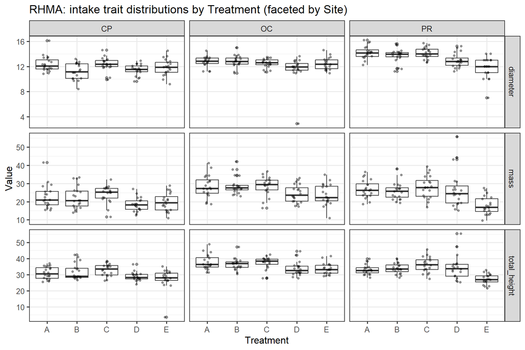

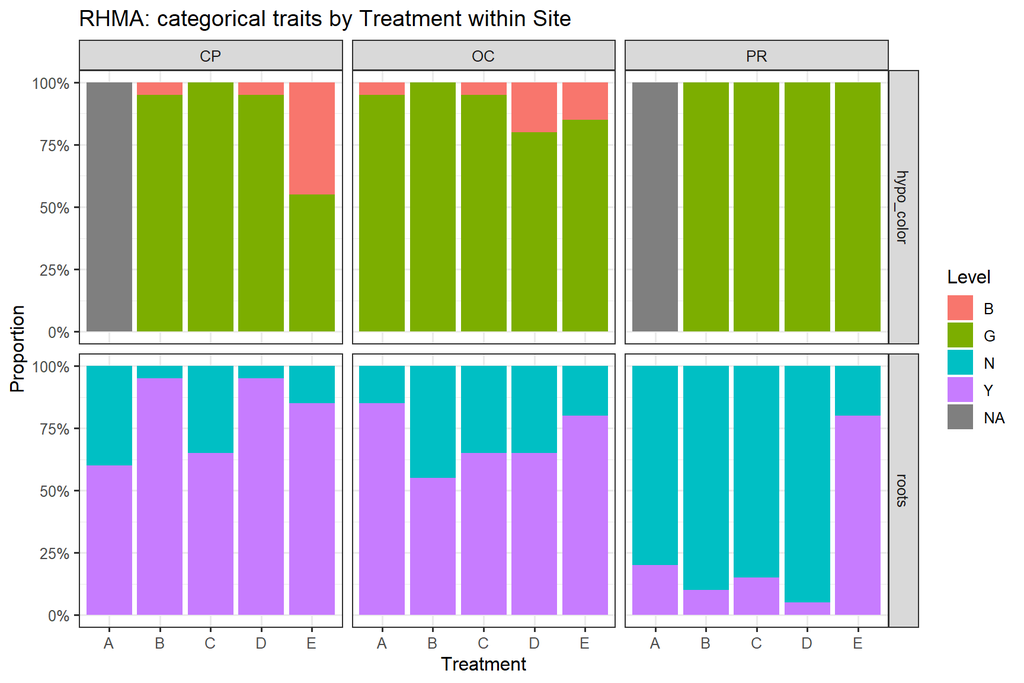

```r
p1 <- rhma_intake %>%
  pivot_longer(all_of(c("total_height","diameter","mass")), names_to = "trait", values_to = "value") %>%
  ggplot(aes(x = treatment, y = value)) +
  geom_boxplot(outlier.alpha = 0.5) +
  geom_jitter(width = 0.15, alpha = 0.4, size = 1) +
  facet_grid(trait ~ site, scales = "free_y") +
  labs(x = "Treatment", y = "Value",
       title = "RHMA: intake trait distributions by Treatment (faceted by Site)") +
  theme_bw(base_size = 12)

p2 <- cat_summary %>%
  ggplot(aes(x = treatment, y = prop, fill = level)) +
  geom_col() +
  facet_grid(trait ~ site) +
  labs(x = "Treatment", y = "Proportion", fill = "Level",
       title = "RHMA: categorical traits by Treatment within Site") +
  scale_y_continuous(labels = scales::percent) +
  theme_bw(base_size = 12)

p1; p2
```

```r
# ggsave(file.path(params$out_dir, "rhma_boxplots.png"), p1, dpi = 300, width = 9, height = 8)
# ggsave(file.path(params$out_dir, "rhma_categorical_props.png"), p2, dpi = 300, width = 9, height = 6)
```

2. LARA Intake 2.1 Read & Clean

```r
lara_raw <- read_csv("C:\\Users\\sarai\\OneDrive\\Email attachments\\Documents\\UVI\\Thesis.Work\\SargMangs\\Data/LARA_IntakeData.csv")
lara0 <- lara_raw %>% clean_names()

# Handle duplicated id columns from "Prop ID" and "Prop_ID"
lara1 <- lara0 %>%
  mutate(
    prop_id = coalesce(!!sym("prop_id")),
    site = str_trim(as.character(site)),
    species = str_trim(as.character(species)),
    treatment = str_trim(as.character(treatment)),
    seed_color = str_squish(as.character(seed_color))
  )

lara2 <- lara1 %>%
  mutate(
    intake_date = parse_mdy_relaxed(intake_date),
    collection_date = {
      cd <- str_extract(collection_date, "\\b\\d{1,2}/\\d{1,2}/\\d{2,4}\\b")
      parse_mdy_relaxed(cd)
    }
  )

num_cols_lara <- c("width","prop_length","rad_length","total_length","mass")
lara3 <- lara2 %>%
  mutate(across(all_of(num_cols_lara), ~ suppressWarnings(as.numeric(str_replace_all(.x, ",", "")))))

lara_intake <- lara3 %>%
  filter(!is.na(intake_date)) %>%
  arrange(prop_id, intake_date) %>%
  group_by(prop_id) %>%
  slice(1) %>%
  ungroup()

glimpse(lara_intake)
```

```
## Rows: 300
## Columns: 16
## $ collection_date <dttm> 2024-10-23, 2024-10-23, 2024-10-23, 2024-10-23, 2024-…
## $ intake_date     <dttm> 2024-10-25, 2024-10-25, 2024-10-25, 2024-10-25, 2024-…
## $ site            <chr> "VB", "VB", "VB", "VB", "VB", "VB", "VB", "VB", "VB", …
## $ species         <chr> "LARA", "LARA", "LARA", "LARA", "LARA", "LARA", "LARA"…
## $ prop_id         <chr> "LA-1", "LA-10", "LA-11", "LA-12", "LA-13", "LA-14", "…
## $ treatment       <chr> "A", "A", "A", "A", "A", "A", "A", "A", "A", "A", "A",…
## $ width           <dbl> 1.00, 1.09, 0.98, 1.34, 1.01, 1.35, 1.30, 1.17, 1.27, …
## $ prop_length     <dbl> 1.80, 1.86, 2.23, 2.52, 1.82, 2.44, 2.36, 2.22, 2.23, …
## $ rad_length      <dbl> 0.00, 0.00, 0.55, 0.00, 0.00, 0.56, 0.44, 0.53, 0.77, …
## $ total_length    <dbl> 1.80, 1.86, 2.78, 2.52, 1.82, 3.00, 2.80, 2.75, 3.00, …
## $ mass            <dbl> 0.33, 0.47, 0.66, 0.92, 0.39, 1.00, 1.03, 0.77, 0.95, …
## $ seed_color      <chr> "B", "G", "G", "G", "G", "G", "G", "G", "G", "G", "G",…
## $ data_collecters <chr> "DN", "DN", "SH, ST", "SH, ST", "SH, ST", "SH, ST", "S…
## $ date_uploaded   <chr> "DIRECT UPLOAD", "DIRECT UPLOAD", "DIRECT UPLOAD", "DI…
## $ data_uploaders  <chr> "DN", "DN", "ST", "ST", "ST", "ST", "ST", "ST", "ST", …
## $ notes           <chr> NA, NA, NA, NA, NA, NA, NA, NA, NA, NA, NA, NA, NA, "M…
```

2.2 QC flags

```r
lara_qc_outliers <- lara_intake %>%
  pivot_longer(all_of(num_cols_lara), names_to = "metric", values_to = "value") %>%
  group_by(metric) %>%
  mutate(
    iqr = IQR(value, na.rm = TRUE),
    Q1 = quantile(value, 0.25, na.rm = TRUE),
    Q3 = quantile(value, 0.75, na.rm = TRUE),
    lower = Q1 - 3*iqr,
    upper = Q3 + 3*iqr,
    is_extreme = value < lower | value > upper
  ) %>%
  ungroup() %>%
  filter(is_extreme & !is.na(value)) %>%
  arrange(metric, desc(value))

lara_qc_lengths <- lara_intake %>%
  mutate(
    calc_total = prop_length + coalesce(rad_length, 0),
    delta_total = total_length - calc_total
  ) %>%
  filter(!is.na(total_length) & !is.na(prop_length)) %>%
  mutate(flag_mismatch = abs(delta_total) > 0.1) %>%
  filter(flag_mismatch) %>%
  select(prop_id, site, treatment, prop_length, rad_length, total_length, calc_total, delta_total)

lara_qc_dates <- lara_intake %>%
  mutate(
    year_intake = year(intake_date),
    year_collect = year(collection_date),
    date_flag = year_intake > 2025 | year_collect > 2025
  ) %>%
  filter(date_flag) %>%
  select(prop_id, site, treatment, collection_date, intake_date)

# Save QC
# readr::write_csv(lara_qc_outliers, file.path(params$out_dir, "lara_qc_flagged_outliers.csv"))
# readr::write_csv(lara_qc_lengths,  file.path(params$out_dir, "lara_qc_total_vs_parts_mismatch.csv"))
# readr::write_csv(lara_qc_dates,    file.path(params$out_dir, "lara_qc_suspicious_dates.csv"))
```

2.3 Summaries

```r
cont_traits_lara <- c("width","prop_length","rad_length","total_length","mass")

lara_cont_summary <- lara_intake %>%
  pivot_longer(all_of(cont_traits_lara), names_to = "trait", values_to = "value") %>%
  group_by(site, treatment, trait) %>%
  summarise(
    n = sum(!is.na(value)),
    mean = mean(value, na.rm = TRUE),
    sd = sd(value, na.rm = TRUE),
    se = sd/sqrt(n),
    .groups = "drop"
  ) %>%
  mutate(mean_sd = sprintf("%.2f ± %.2f", mean, sd))

lara_cat_summary <- lara_intake %>%
  count(site, treatment, seed_color, name = "n") %>%
  group_by(site, treatment) %>%
  mutate(prop = n / sum(n)) %>%
  ungroup() %>%
  rename(level = seed_color) %>%
  mutate(trait = "seed_color")


lara_norm_homo <- check_normality_homogeneity(lara_intake, cont_traits_lara)
lara_norm_homo
```

```
## # A tibble: 5 × 4
##   trait        shapiro_resid_p levene_p bartlett_p
##   <chr>                  <dbl>    <dbl>      <dbl>
## 1 width               1.08e- 8 8.19e- 2   4.77e- 4
## 2 prop_length         1.52e- 1 8.27e- 8   2.36e- 9
## 3 rad_length          6.34e-21 1.11e- 2   0
## 4 total_length        1.79e-15 6.65e- 3   1.11e-18
## 5 mass                1.32e- 4 1.29e-13   7.33e-16
```

```r
knitr::kable(lara_cont_summary %>% arrange(trait, site, treatment), caption = "LARA continuous traits by Site × Treatment")
```

LARA continuous traits by Site × Treatment

| site | treatment | trait | n | mean | sd | se | mean_sd |
| --- | --- | --- | --- | --- | --- | --- | --- |
| MB | A | mass | 20 | 0.5205 | 0.1089894 | 0.0243708 | 0.52 ± 0.11 |
| MB | B | mass | 20 | 0.4355 | 0.0792381 | 0.0177182 | 0.44 ± 0.08 |
| MB | C | mass | 20 | 0.6130 | 0.1152160 | 0.0257631 | 0.61 ± 0.12 |
| MB | D | mass | 20 | 0.5380 | 0.0709039 | 0.0158546 | 0.54 ± 0.07 |
| MB | E | mass | 20 | 0.6165 | 0.1174857 | 0.0262706 | 0.62 ± 0.12 |
| PR | A | mass | 20 | 0.7350 | 0.1154169 | 0.0258080 | 0.73 ± 0.12 |
| PR | B | mass | 20 | 0.7375 | 0.1562682 | 0.0349426 | 0.74 ± 0.16 |
| PR | C | mass | 20 | 0.6435 | 0.0772061 | 0.0172638 | 0.64 ± 0.08 |
| PR | D | mass | 20 | 0.6880 | 0.1516436 | 0.0339085 | 0.69 ± 0.15 |
| PR | E | mass | 20 | 0.7000 | 0.1243509 | 0.0278057 | 0.70 ± 0.12 |
| VB | A | mass | 20 | 0.6490 | 0.2402827 | 0.0537289 | 0.65 ± 0.24 |
| VB | B | mass | 20 | 0.6425 | 0.2797720 | 0.0625589 | 0.64 ± 0.28 |
| VB | C | mass | 20 | 0.6895 | 0.2621063 | 0.0586088 | 0.69 ± 0.26 |
| VB | D | mass | 20 | 0.5235 | 0.1550984 | 0.0346811 | 0.52 ± 0.16 |
| VB | E | mass | 20 | 0.3405 | 0.0877481 | 0.0196211 | 0.34 ± 0.09 |
| MB | A | prop_length | 20 | 1.7160 | 0.1495748 | 0.0334460 | 1.72 ± 0.15 |
| MB | B | prop_length | 20 | 1.8300 | 0.1490320 | 0.0333246 | 1.83 ± 0.15 |
| MB | C | prop_length | 20 | 1.6850 | 0.1954078 | 0.0436945 | 1.68 ± 0.20 |
| MB | D | prop_length | 20 | 1.7150 | 0.1424411 | 0.0318508 | 1.72 ± 0.14 |
| MB | E | prop_length | 20 | 1.6870 | 0.1457503 | 0.0325908 | 1.69 ± 0.15 |
| PR | A | prop_length | 20 | 1.9915 | 0.2066595 | 0.0462105 | 1.99 ± 0.21 |
| PR | B | prop_length | 20 | 2.1200 | 0.4479192 | 0.1001578 | 2.12 ± 0.45 |
| PR | C | prop_length | 20 | 1.8950 | 0.2064104 | 0.0461548 | 1.90 ± 0.21 |
| PR | D | prop_length | 20 | 1.9825 | 0.2916717 | 0.0652198 | 1.98 ± 0.29 |
| PR | E | prop_length | 20 | 1.8855 | 0.2011670 | 0.0449823 | 1.89 ± 0.20 |
| VB | A | prop_length | 20 | 2.1165 | 0.2610561 | 0.0583739 | 2.12 ± 0.26 |
| VB | B | prop_length | 20 | 2.1300 | 0.3419757 | 0.0764681 | 2.13 ± 0.34 |
| VB | C | prop_length | 20 | 2.1190 | 0.3725573 | 0.0833063 | 2.12 ± 0.37 |
| VB | D | prop_length | 20 | 1.9600 | 0.2854360 | 0.0638254 | 1.96 ± 0.29 |
| VB | E | prop_length | 20 | 1.8210 | 0.2619341 | 0.0585702 | 1.82 ± 0.26 |
| MB | A | rad_length | 20 | 0.0250 | 0.0638666 | 0.0142810 | 0.02 ± 0.06 |
| MB | B | rad_length | 20 | 0.0000 | 0.0000000 | 0.0000000 | 0.00 ± 0.00 |
| MB | C | rad_length | 20 | 0.4850 | 0.2109502 | 0.0471699 | 0.48 ± 0.21 |
| MB | D | rad_length | 20 | 0.4050 | 0.8611345 | 0.1925555 | 0.40 ± 0.86 |
| MB | E | rad_length | 20 | 0.6235 | 0.3094014 | 0.0691843 | 0.62 ± 0.31 |
| PR | A | rad_length | 20 | 0.3340 | 0.3906459 | 0.0873511 | 0.33 ± 0.39 |
| PR | B | rad_length | 20 | 0.4450 | 0.8223682 | 0.1838871 | 0.44 ± 0.82 |
| PR | C | rad_length | 20 | 0.6850 | 0.7815470 | 0.1747592 | 0.68 ± 0.78 |
| PR | D | rad_length | 20 | 0.4100 | 0.7876681 | 0.1761279 | 0.41 ± 0.79 |
| PR | E | rad_length | 20 | 0.4425 | 0.2401288 | 0.0536944 | 0.44 ± 0.24 |
| VB | A | rad_length | 20 | 0.2415 | 0.2975740 | 0.0665396 | 0.24 ± 0.30 |
| VB | B | rad_length | 20 | 0.1400 | 0.2010499 | 0.0449561 | 0.14 ± 0.20 |
| VB | C | rad_length | 20 | 0.5500 | 0.5021008 | 0.1122732 | 0.55 ± 0.50 |
| VB | D | rad_length | 20 | 0.3650 | 0.4055860 | 0.0906918 | 0.36 ± 0.41 |
| VB | E | rad_length | 20 | 0.3250 | 0.5680113 | 0.1270112 | 0.32 ± 0.57 |
| MB | A | total_length | 20 | 1.7410 | 0.1692989 | 0.0378564 | 1.74 ± 0.17 |
| MB | B | total_length | 20 | 1.8300 | 0.1490320 | 0.0333246 | 1.83 ± 0.15 |
| MB | C | total_length | 20 | 2.1700 | 0.2939746 | 0.0657347 | 2.17 ± 0.29 |
| MB | D | total_length | 20 | 2.1200 | 0.8900621 | 0.1990239 | 2.12 ± 0.89 |
| MB | E | total_length | 20 | 2.3105 | 0.3817891 | 0.0853706 | 2.31 ± 0.38 |
| PR | A | total_length | 20 | 2.3255 | 0.4225919 | 0.0944944 | 2.33 ± 0.42 |
| PR | B | total_length | 20 | 2.5650 | 0.6417698 | 0.1435041 | 2.56 ± 0.64 |
| PR | C | total_length | 20 | 2.5800 | 0.7466416 | 0.1669541 | 2.58 ± 0.75 |
| PR | D | total_length | 20 | 2.3925 | 0.7787093 | 0.1741247 | 2.39 ± 0.78 |
| PR | E | total_length | 20 | 2.3280 | 0.3222389 | 0.0720548 | 2.33 ± 0.32 |
| VB | A | total_length | 20 | 2.3580 | 0.5075182 | 0.1134845 | 2.36 ± 0.51 |
| VB | B | total_length | 20 | 2.2700 | 0.4791440 | 0.1071398 | 2.27 ± 0.48 |
| VB | C | total_length | 20 | 2.6690 | 0.8025348 | 0.1794522 | 2.67 ± 0.80 |
| VB | D | total_length | 20 | 2.3250 | 0.5260328 | 0.1176245 | 2.33 ± 0.53 |
| VB | E | total_length | 20 | 2.1460 | 0.7900060 | 0.1766507 | 2.15 ± 0.79 |
| MB | A | width | 20 | 1.0765 | 0.1068829 | 0.0238997 | 1.08 ± 0.11 |
| MB | B | width | 20 | 1.2100 | 0.1165287 | 0.0260566 | 1.21 ± 0.12 |
| MB | C | width | 20 | 1.1200 | 0.1105013 | 0.0247088 | 1.12 ± 0.11 |
| MB | D | width | 20 | 1.1550 | 0.1394538 | 0.0311828 | 1.16 ± 0.14 |
| MB | E | width | 20 | 1.1315 | 0.0969685 | 0.0216828 | 1.13 ± 0.10 |
| PR | A | width | 20 | 1.2690 | 0.1155263 | 0.0258325 | 1.27 ± 0.12 |
| PR | B | width | 20 | 1.2150 | 0.1631112 | 0.0364728 | 1.22 ± 0.16 |
| PR | C | width | 20 | 1.1750 | 0.1019546 | 0.0227977 | 1.18 ± 0.10 |
| PR | D | width | 20 | 1.2405 | 0.1601471 | 0.0358100 | 1.24 ± 0.16 |
| PR | E | width | 20 | 1.1710 | 0.0919325 | 0.0205567 | 1.17 ± 0.09 |
| VB | A | width | 20 | 1.0965 | 0.1548267 | 0.0346203 | 1.10 ± 0.15 |
| VB | B | width | 20 | 1.1350 | 0.1460894 | 0.0326666 | 1.14 ± 0.15 |
| VB | C | width | 20 | 1.0455 | 0.1319280 | 0.0295000 | 1.05 ± 0.13 |
| VB | D | width | 20 | 1.0400 | 0.2392972 | 0.0535085 | 1.04 ± 0.24 |
| VB | E | width | 20 | 0.9625 | 0.1697018 | 0.0379465 | 0.96 ± 0.17 |

```r
knitr::kable(lara_cat_summary %>% arrange(site, treatment, level), caption = "LARA seed color proportions")
```

LARA seed color proportions

| site | treatment | level | n | prop | trait |
| --- | --- | --- | --- | --- | --- |
| MB | A | G | 16 | 0.80 | seed_color |
| MB | A | GB | 3 | 0.15 | seed_color |
| MB | A | YG | 1 | 0.05 | seed_color |
| MB | B | G | 20 | 1.00 | seed_color |
| MB | C | B | 20 | 1.00 | seed_color |
| MB | D | B | 20 | 1.00 | seed_color |
| MB | E | B | 20 | 1.00 | seed_color |
| PR | A | B | 9 | 0.45 | seed_color |
| PR | A | G | 11 | 0.55 | seed_color |
| PR | B | G | 14 | 0.70 | seed_color |
| PR | B | NA | 6 | 0.30 | seed_color |
| PR | C | B | 9 | 0.45 | seed_color |
| PR | C | G | 11 | 0.55 | seed_color |
| PR | D | B | 12 | 0.60 | seed_color |
| PR | D | G | 8 | 0.40 | seed_color |
| PR | E | B | 9 | 0.45 | seed_color |
| PR | E | G | 11 | 0.55 | seed_color |
| VB | A | B | 4 | 0.20 | seed_color |
| VB | A | G | 16 | 0.80 | seed_color |
| VB | B | B | 7 | 0.35 | seed_color |
| VB | B | G | 13 | 0.65 | seed_color |
| VB | C | B | 18 | 0.90 | seed_color |
| VB | C | G | 2 | 0.10 | seed_color |
| VB | D | B | 14 | 0.70 | seed_color |
| VB | D | G | 6 | 0.30 | seed_color |
| VB | E | B | 9 | 0.45 | seed_color |
| VB | E | G | 11 | 0.55 | seed_color |

```r
# readr::write_csv(lara_cont_summary, file.path(params$out_dir, "lara_continuous_summary_by_site_treatment.csv"))
# readr::write_csv(lara_cat_summary,  file.path(params$out_dir, "lara_seedcolor_summary_by_site_treatment.csv"))
```

Tukey HSD

```r
# Helper to fit model with or without Species (if present)
.lara_fit_for <- function(df, resp){
  if (dplyr::n_distinct(df$species) > 1) {
    lm(reformulate(c("site","treatment","site:treatment","species"), response = resp), data = df)
  } else {
    lm(reformulate(c("site","treatment","site:treatment"), response = resp), data = df)
  }
}

lara_tukey_pairs <- purrr::map_dfr(cont_traits_lara, function(tr){
  df <- lara_intake %>% dplyr::select(site, treatment, species, !!rlang::sym(tr)) %>% tidyr::drop_na()
  if (nrow(df) < 5 || dplyr::n_distinct(df$treatment) < 2) {
    return(tibble(trait = tr, note = "Insufficient data for Tukey"))
  }
  fit <- .lara_fit_for(df, tr)
  emm <- emmeans::emmeans(fit, ~ treatment | site)
  cmp <- emmeans::contrast(emm, method = "pairwise", adjust = "tukey")
  as_tibble(summary(cmp)) %>%
    dplyr::mutate(trait = tr)
})

lara_emm <- purrr::map_dfr(cont_traits_lara, function(tr){
  df <- lara_intake %>% dplyr::select(site, treatment, species, !!rlang::sym(tr)) %>% tidyr::drop_na()
  if (nrow(df) < 5 || dplyr::n_distinct(df$treatment) < 2) return(tibble())
  fit <- .lara_fit_for(df, tr)
  emm <- emmeans::emmeans(fit, ~ treatment | site)
  as_tibble(summary(emm)) %>% dplyr::mutate(trait = tr)
})

# readr::write_csv(lara_tukey_pairs, file.path(params$out_dir, "lara_tukey_pairs.csv"))
# readr::write_csv(lara_emm,         file.path(params$out_dir, "lara_emmeans.csv"))
```

2.4 Hypothesis tests Data did not meet normality so I had to use a different test. non-parametric ones

```r
lara_anova <- purrr::map_dfr(cont_traits_lara, function(tr){
  df <- lara_intake %>% select(site, treatment, species, !!sym(tr)) %>% drop_na()
  if(nrow(df) < 5) return(tibble(trait = tr, term = NA, statistic = NA, p.value = NA, note = "Too few rows for ANOVA"))
  if(dplyr::n_distinct(df$species) > 1){
    fit <- lm(reformulate(termlabels = c("site","treatment","site:treatment","species"), response = tr), data = df)
  } else {
    fit <- lm(reformulate(termlabels = c("site","treatment","site:treatment"), response = tr), data = df)
  }
  broom::tidy(anova(fit)) %>% mutate(trait = tr)
})

lara_chisq <- {
  tab_site <- lara_intake %>% count(site, seed_color) %>% pivot_wider(names_from = seed_color, values_from = n, values_fill = 0)
  chi_site <- tryCatch(chisq.test(as.matrix(tab_site[,-1])), error = function(e) NULL)

  tab_trt <- lara_intake %>% count(treatment, seed_color) %>% pivot_wider(names_from = seed_color, values_from = n, values_fill = 0)
  chi_trt <- tryCatch(chisq.test(as.matrix(tab_trt[,-1])), error = function(e) NULL)

  tibble(
    trait = "seed_color",
    test  = c("ChiSq across Site","ChiSq across Treatment"),
    statistic = c(if(!is.null(chi_site)) chi_site$statistic else NA,
                  if(!is.null(chi_trt)) chi_trt$statistic else NA),
    df = c(if(!is.null(chi_site)) chi_site$parameter else NA,
           if(!is.null(chi_trt)) chi_trt$parameter else NA),
    p_value = c(if(!is.null(chi_site)) chi_site$p.value else NA,
                if(!is.null(chi_trt)) chi_trt$p.value else NA)
  )
}

# lara_report_anova <- lara_anova %>%
#   mutate(term = recode(term,
#                        "site" = "Site",
#                        "treatment" = "Treatment",
#                        "site:treatment" = "Site×Treatment",
#                        .default = term)) %>%
#   filter(!is.na(p.value), term != "Residuals") %>%  # optional filter
#   select(trait, term, p.value) %>%
#   mutate(sig = case_when(
#     p.value < 0.001 ~ "***",
#     p.value < 0.01  ~ "**",
#     p.value < 0.05  ~ "*",
#     TRUE ~ "ns"
#   )) %>%
#   arrange(trait, term)

lara_report_anova <- lara_anova %>%
  mutate(
    term = dplyr::case_match(
      tolower(as.character(term)),
      "site" ~ "Site",
      "treatment" ~ "Treatment",
      "site:treatment" ~ "Site×Treatment",
      .default = as.character(term)
    )
  ) %>%
  filter(!is.na(p.value), term != "Residuals") %>%
  select(trait, term, p.value) %>%
  mutate(sig = case_when(
    p.value < 0.001 ~ "***",
    p.value < 0.01  ~ "**",
    p.value < 0.05  ~ "*",
    TRUE ~ "ns"
  )) %>%
  arrange(trait, term)

knitr::kable(lara_report_anova, caption = "LARA ANOVA significance")
```

LARA ANOVA significance

| trait | term | p.value | sig |
| --- | --- | --- | --- |
| mass | Site | 0.0000000 | *** |
| mass | Site×Treatment | 0.0000000 | *** |
| mass | Treatment | 0.0060294 | ** |
| prop_length | Site | 0.0000000 | *** |
| prop_length | Site×Treatment | 0.1567948 | ns |
| prop_length | Treatment | 0.0000838 | *** |
| rad_length | Site | 0.0607555 | ns |
| rad_length | Site×Treatment | 0.1817319 | ns |
| rad_length | Treatment | 0.0000613 | *** |
| total_length | Site | 0.0000021 | *** |
| total_length | Site×Treatment | 0.0479742 | * |
| total_length | Treatment | 0.0298695 | * |
| width | Site | 0.0000000 | *** |
| width | Site×Treatment | 0.0327514 | * |
| width | Treatment | 0.0026445 | ** |

```r
knitr::kable(lara_chisq, caption = "LARA Chi-squared tests")
```

LARA Chi-squared tests

| trait | test | statistic | df | p_value |
| --- | --- | --- | --- | --- |
| seed_color | ChiSq across Site | 28.44919 | 8 | 0.000396 |
| seed_color | ChiSq across Treatment | 124.75582 | 16 | 0.000000 |

```r
# readr::write_csv(lara_anova, file.path(params$out_dir, "lara_anova_results.csv"))
# readr::write_csv(lara_chisq, file.path(params$out_dir, "lara_seedcolor_chisq_results.csv"))
```

```r
kruskal_lara <- map_dfr(cont_traits_lara, function(tr) {
  df <- lara_intake %>% select(site, treatment, !!sym(tr)) %>% drop_na()
  map_dfr(unique(df$site), function(s) {
    sub <- df %>% filter(site == s)
    if(n_distinct(sub$treatment) > 1) {
      kw <- kruskal.test(reformulate("treatment", tr), data = sub)
      tibble(site = s, trait = tr, p_value = kw$p.value, statistic = kw$statistic)
    } else {
      tibble(site = s, trait = tr, p_value = NA, statistic = NA)
    }
  })
})

kruskal_lara
```

```
## # A tibble: 15 × 4
##    site  trait         p_value statistic
##    <chr> <chr>           <dbl>     <dbl>
##  1 VB    width        7.29e- 3     14.0
##  2 MB    width        1.09e- 2     13.1
##  3 PR    width        1.12e- 1      7.50
##  4 VB    prop_length  4.37e- 3     15.2
##  5 MB    prop_length  3.54e- 2     10.3
##  6 PR    prop_length  5.78e- 2      9.14
##  7 VB    rad_length   7.32e- 2      8.56
##  8 MB    rad_length   6.99e-15     72.4
##  9 PR    rad_length   7.76e- 3     13.9
## 10 VB    total_length 9.00e- 2      8.04
## 11 MB    total_length 4.97e- 9     44.5
## 12 PR    total_length 1.89e- 1      6.14
## 13 VB    mass         2.14e- 6     31.8
## 14 MB    mass         6.48e- 7     34.3
## 15 PR    mass         4.78e- 2      9.60
```

```r
dunn_lara <- map_dfr(cont_traits_lara, function(tr) {
  df <- lara_intake %>% select(site, treatment, !!sym(tr)) %>% drop_na()
  map_dfr(unique(df$site), function(s) {
    sub <- df %>% filter(site == s)
    if(n_distinct(sub$treatment) > 1) {
      dt <- dunnTest(reformulate("treatment", tr), data = sub, method = "bonferroni")
      out <- dt$res
      out$trait <- tr
      out$site <- s
      out
    } else {
      tibble()
    }
  })
})

head(dunn_lara)
```

```
##   Comparison          Z    P.unadj     P.adj trait site
## 1      A - B -0.8397732 0.40103554 1.0000000 width   VB
## 2      A - C  0.8123297 0.41660249 1.0000000 width   VB
## 3      B - C  1.6521029 0.09851357 0.9851357 width   VB
## 4      A - D  1.5313512 0.12568262 1.0000000 width   VB
## 5      B - D  2.3711244 0.01773406 0.1773406 width   VB
## 6      C - D  0.7190215 0.47212765 1.0000000 width   VB
```

2.5 Plots

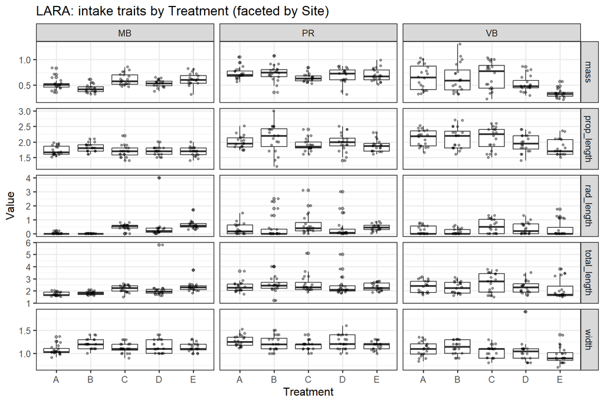

```r
p_lara_box <- lara_intake %>%
  pivot_longer(all_of(c("total_length","prop_length","rad_length","width","mass")),
               names_to = "trait", values_to = "value") %>%
  ggplot(aes(x = treatment, y = value)) +
  geom_boxplot(outlier.alpha = 0.5) +
  geom_jitter(width = 0.15, alpha = 0.4, size = 1) +
  facet_grid(trait ~ site, scales = "free_y") +
  labs(x = "Treatment", y = "Value",
       title = "LARA: intake traits by Treatment (faceted by Site)") +
  theme_bw(base_size = 12)

p_lara_seed <- lara_cat_summary %>%
  ggplot(aes(x = treatment, y = prop, fill = level)) +
  geom_col() +
  facet_grid(~ site) +
  labs(x = "Treatment", y = "Proportion", fill = "Seed Color",
       title = "LARA: seed color at intake by Treatment within Site") +
  scale_y_continuous(labels = scales::percent) +
  theme_bw(base_size = 12)

p_lara_box
```

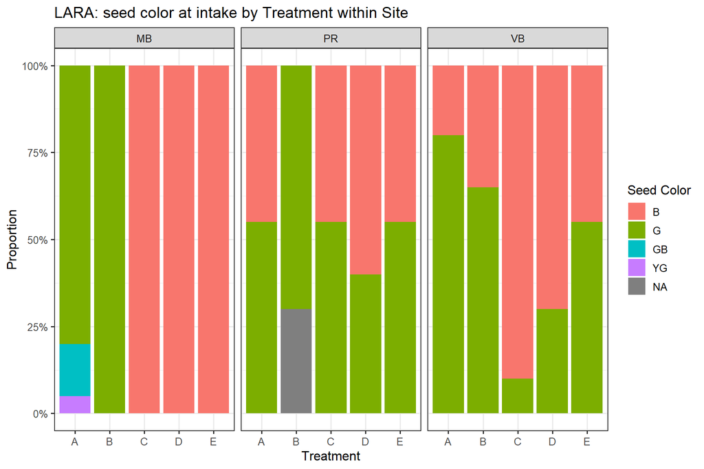

```r
p_lara_seed
```

```r
# ggsave(file.path(params$out_dir, "lara_boxplots.png"), p_lara_box, dpi = 300, width = 9, height = 8)
# ggsave(file.path(params$out_dir, "lara_seedcolor_props.png"), p_lara_seed, dpi = 300, width = 9, height = 6)
```

Here’s a tight, peer-review–style assessment of what you’ve got so far, with actionably specific notes.

# RHMA — Intake (1.x)

## Assumption checks (normality/variance)

- **Residual normality:** Strongly **violated** for *all* RHMA continuous traits (Shapiro p ≪ .05), so strict ANOVA assumptions don’t hold.
- **Homogeneity (Levene):** Mostly **OK** (Equal Var) **except** `rhma_height_1` (p≈.018) and `rhma_height_2` (p≈.041) → heteroscedasticity there. **Implication:** For inference, prefer (a) robust/heteroskedastic-consistent SEs, or (b) non-parametric alternatives; classic ANOVA will tend to inflate Type-I error for the height traits.

## Descriptives: broad patterns

From the site×treatment means:

- **Site effects are large and consistent** (e.g., OC tends to be tallest/heaviest; PR tends to have bigger diameters).
- **Treatment effects are also strong** and sometimes **site-dependent** (interaction visible in several traits). Example signals:
  - `total_height` & `mass`: Treatment **E** is notably lower at **PR** and often at **OC** vs A–C.
  - `diameter`: PR > OC ≳ CP overall; D often lower within sites.
- **Categoricals:**
  - `hypo_color` differs by *site* (e.g., PR nearly all “G”; OC has some “B” in D/E) and by *treatment* (E shows more non-G at CP/OC).
  - `roots` shows **pronounced site differences**: PR has high **N** (no roots) proportions, whereas CP/OC lean **Y** (rooted).

## Formal tests

- **Parametric two-way ANOVA (lm on raw):**
  - For **every continuous trait**, **Site** and **Treatment** main effects are **highly significant** (p < .001 in most).
  - **Site×Treatment interactions** are **often significant** (e.g., diameter, epi_length, hypo_length, heights, total_height), confirming treatment effects vary by site.
  - Given non-normality (and some heteroscedasticity), treat these p-values as **indicative**, not definitive.
- **Non-parametric per-site Kruskal–Wallis** (Treatment effect within each Site):
  - Many **significant** results across OC/CP/PR for diameter, epi_length, hypo_length, total_height, mass (e.g., PR diameter p≈2.4e-7; OC total_height p≈4.7e-4).
  - **Dunn (Bonferroni)** post-hoc: Contrasts frequently show **D vs A/B** as significant (direction consistent with lower D/E means where noted).
- **Categoricals (χ²):**
  - `hypo_color` differs by **Site** (p≈1e-6) and **Treatment** (p<1e-6).
  - `roots` differs **strongly by Site** (p<1e-6) and **by Treatment** (p≈0.0018). These are robust to non-normality (assumes adequate expected counts; your tables are well-populated).

## Post-hoc via EMMs (Tukey)

- Your `emmeans` by Site with Tukey adjustment is an excellent way to **map the interaction**. Keep it, but **pair it with** either:
  - a **rank-based** analogue (e.g., **ART**: aligned-rank transform two-way ANOVA) **or**
  - **heteroskedastic-robust** linear models (HC3/HC4 SEs), so inference is consistent with diagnostics.

## Visualization

- Box/jitter grids by `trait ~ site` neatly show **spread and interaction**; keep `free_y`.
- Stacked bars for categorical proportions are clear; consider adding **exact `%` labels** inside bars for camera-ready figures.

# LARA — Intake (2.x)

## Assumption checks

- **Residual normality:** Violated for most traits (width, rad_length, total_length, mass).
- **Variance homogeneity:** Multiple **Levene p < .05** (rad_length, total_length, mass). **Implication:** Prefer non-parametric or robust methods for confirmatory tests.

# Interpretation & Reporting Guidance

## 2) Caveats you should state in Methods

- Residuals are **non-normal** and some traits are **heteroskedastic** → Classic ANOVA p-values are **not** your primary confirmatory inference; they’re supportive/descriptive.
- You conducted **non-parametric** within-site tests (Kruskal–Wallis + Dunn with Bonferroni), which are the **primary** inferential results for intake differences.
- Multiple testing across many traits & sites → control **familywise rate** or **FDR** (Bonferroni is conservative; BH/FDR is acceptable if you justify it).

## 3) Recommended upgrades (fast wins)

- **Robust 2-way approach:** Re-fit `lm` per trait with **HC3** SEs via `sandwich` + `lmtest::coeftest`, and run **Wald tests** for `Site`, `Treatment`, `Site×Treatment`. Report robust p’s alongside EMMs.
- **Rank-based 2-way** (if you want a fully non-parametric factorial): **ARTool** (`ART` + `ARTool::anova(art_model)`), then **ART-EMMs** for post-hoc contrasts.
- **Effect sizes:**
  - Parametric: partial **η²** for ANOVA tables; **Cohen’s d** (or **Hedges g**) for pairwise Tukey contrasts (use `emmeans::eff_size`).
  - Non-parametric: report **Cliff’s delta** or **rank-biserial r** for Dunn pairs.
- **QC loop:** Manually check the 4 flagged RHMA rows + LARA length mismatches; keep a tiny appendix table “records corrected”.

## 5) What to carry forward into longitudinal models

- Because baseline (intake) differs, **include intake covariates** (e.g., total height, mass, diameter, seed/hypo color, root presence) or their **site-centered** forms in your GLMMs for survival/growth.
- Consider **propensity-like adjustment** at the site level (e.g., include Site × Treatment and intake trait(s)) to account for baseline imbalance.
- For plots, add **site-specific EMMs with CIs** (robust) to emphasize interaction, not just raw boxplots.

## Minor code notes (quality-of-life)

- Your `case_match` switch for terms is great—keeps things robust to factor label casing.
- Where Shapiro is used, continue to test **residuals** (not raw values)—you already do this correctly.
- For Dunn, Bonferroni is fine; if power is a concern and you can justify, **Holm** is uniformly better than Bonferroni.
- For χ², quickly check **expected counts ≥5**; if any are <5, swap to **Fisher–Freeman–Halton** (extension of Fisher’s exact) for the affected table.

### Bottom line

- **Strong, consistent evidence** of **site** and **treatment** differences **at intake** for both species, with **site-specific treatment rankings**.
- Your **non-parametric** and **EMM** workflows appropriately triangulate these effects given assumption violations.
- Clean up the flagged records, add **robust ANOVA** (or **ART**) for factorial inference, and report **effect sizes**.
- Then **carry intake covariates forward** in your GLMMs so downstream effects aren’t confounded by baseline imbalance.